# HW3_TS_KatieBaerveldt

*c. What can you learn from the PACF graph?*

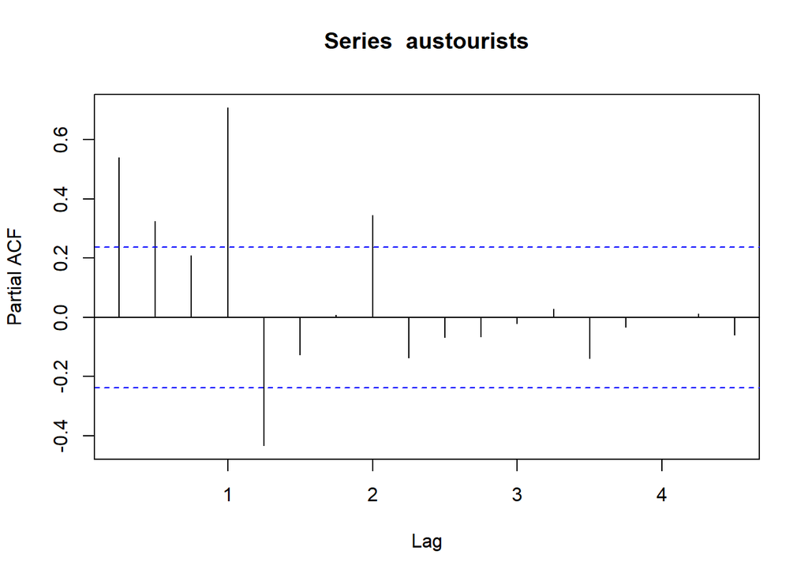

```r
pacf(austourists)
```

There are only 5 significant lags in my PACF plot. The correlation of the residuals of my lags seem to only have significants in the first two seasons of my data.

*d. Produce plots of the seasonally differenced data (1−B4)Yt. What model do these graphs suggest?*

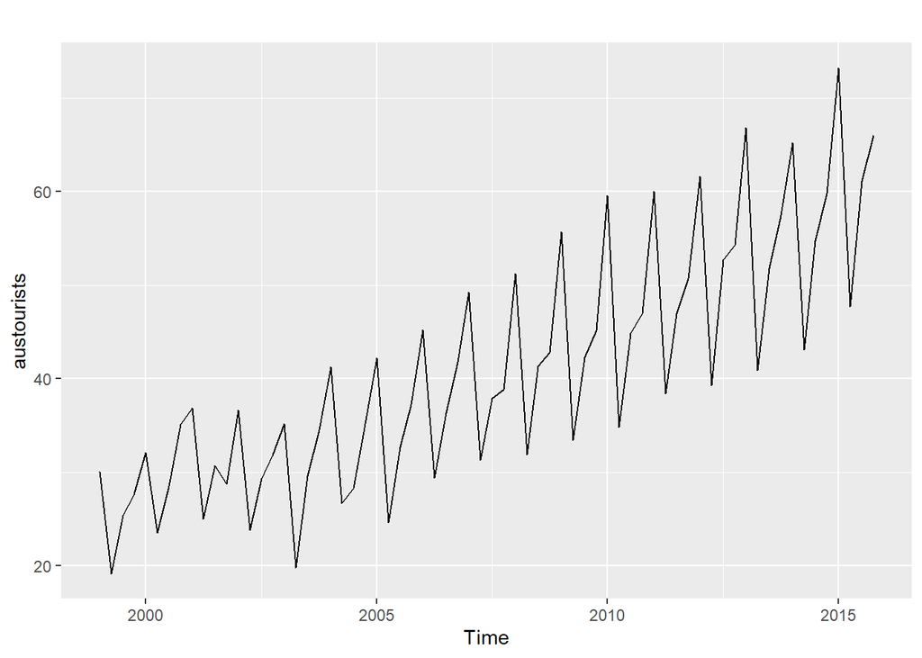

```r
autoplot(austourists)
```

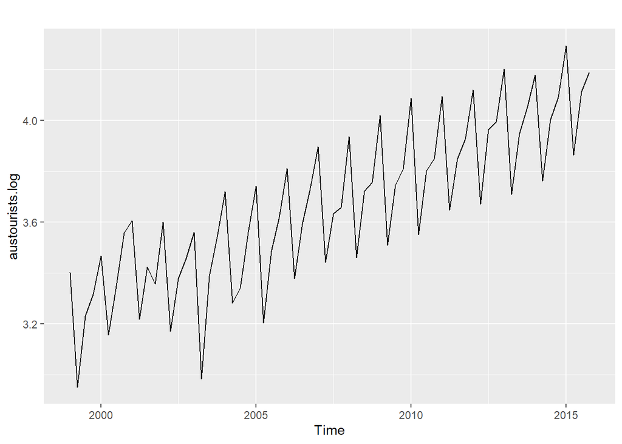

```r
austourists.log <- log(austourists)
autoplot(austourists.log)
```

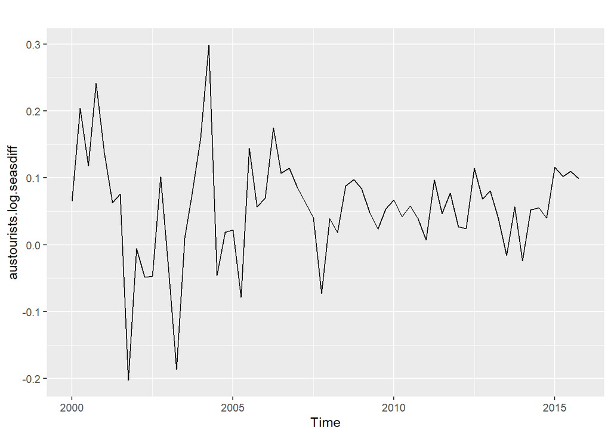

```r
austourists.log.seasdiff <- diff(austourists.log, 4)
autoplot(austourists.log.seasdiff)
```

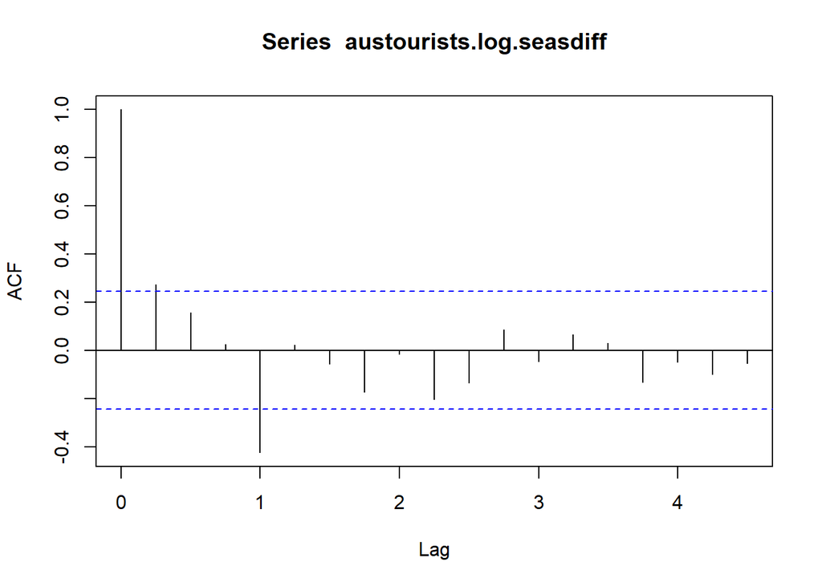

```r
# Testing to see effectiveness of model
acf(austourists.log.seasdiff)
```

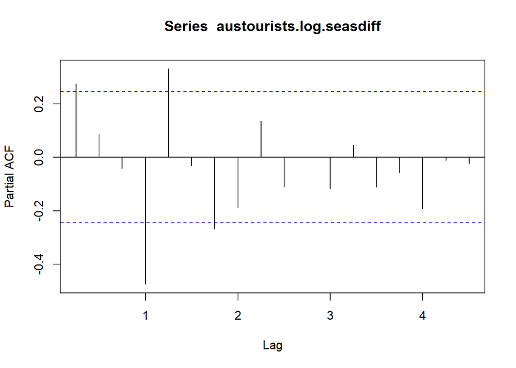

```r
pacf(austourists.log.seasdiff)
```

```r
Box.test(austourists.log.seasdiff,lag=4,type='Ljung')
```

```
##
##  Box-Ljung test
##
## data:  austourists.log.seasdiff
## X-squared = 19.424, df = 4, p-value = 0.0006488
```

This suggests that we were able to make the data more stationary, but we’re not quite where we need to be just yet when evaluating the ACF and box test. I’ve decided to perform differencing:

```r
ndiffs(austourists.log.seasdiff)
```

```
## [1] 0
```

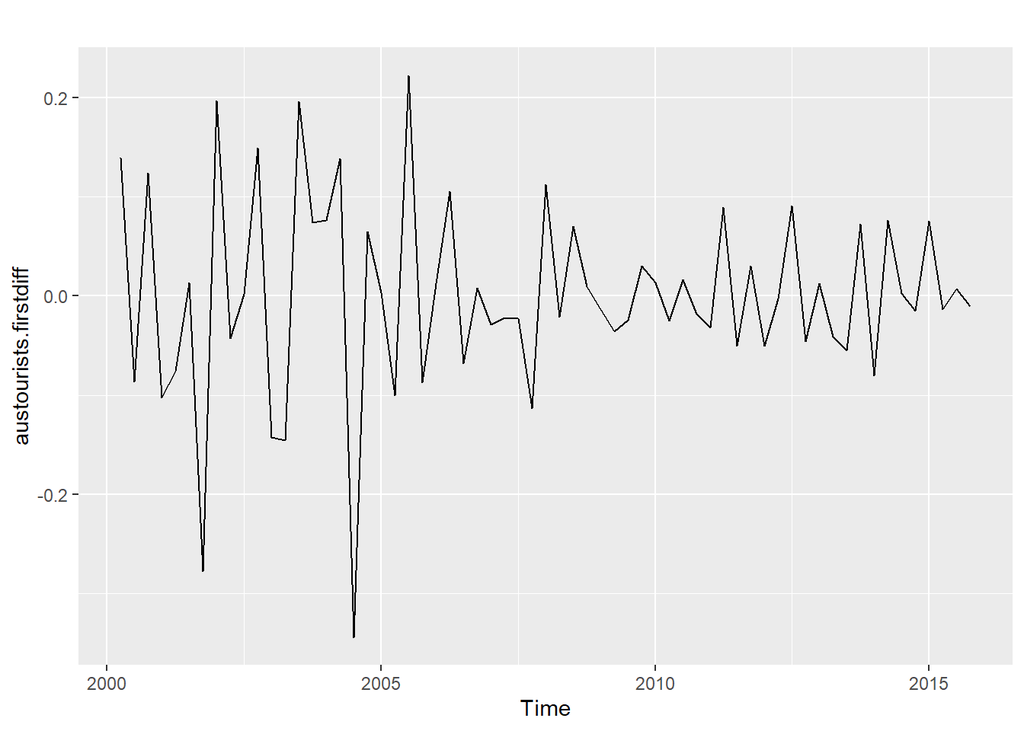

```r
austourists.firstdiff <- diff(austourists.log.seasdiff)
autoplot(austourists.firstdiff)
```

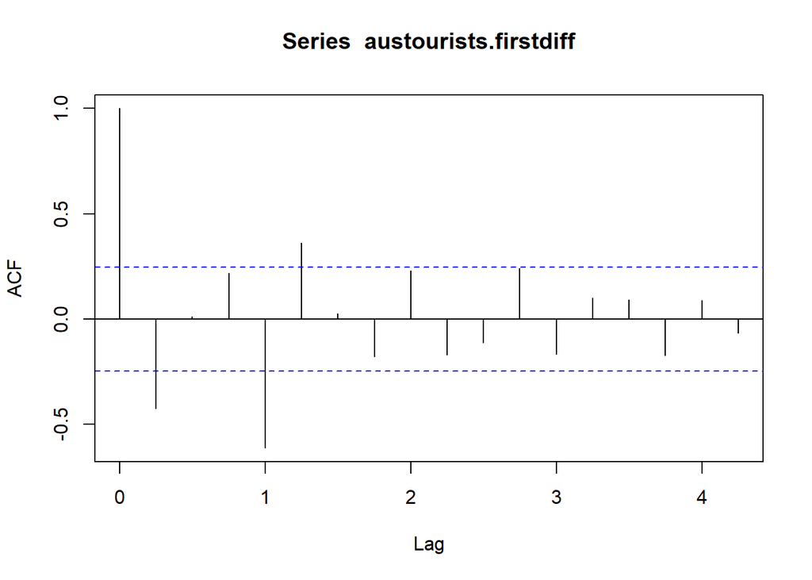

```r
acf(austourists.firstdiff)
```

```r
Box.test(austourists.firstdiff,lag=4,type='Ljung')
```

```
##
##  Box-Ljung test
##
## data:  austourists.firstdiff
## X-squared = 41.033, df = 4, p-value = 2.646e-08
```

My ndiffs function confirms what I found by manually performing differencing - it doesn’t seem to help stabalize the data. Now that I have a constant, 0, for my difference variable, I will test some ARIMA fits:

```r
fit1.austourists <- Arima(austourists.log.seasdiff, order=c(1,0,0), seasonal=c(1,0,0)) #AR focused
fit2.austourists <- Arima(austourists.log.seasdiff, order=c(0,0,1), seasonal=c(0,0,1)) #MA focused

fit1.austourists
```

```
## Series: austourists.log.seasdiff
## ARIMA(1,0,0)(1,0,0)[4] with non-zero mean
##
## Coefficients:
##          ar1     sar1    mean
##       0.4463  -0.5850  0.0527
## s.e.  0.1150   0.1036  0.0092
##
## sigma^2 estimated as 0.004302:  log likelihood=84.15
## AIC=-160.31   AICc=-159.63   BIC=-151.67
```

```r
fit2.austourists
```

```
## Series: austourists.log.seasdiff
## ARIMA(0,0,1)(0,0,1)[4] with non-zero mean
##
## Coefficients:
##          ma1     sma1    mean
##       0.2787  -1.0000  0.0524
## s.e.  0.1024   0.2219  0.0018
##
## sigma^2 estimated as 0.003259:  log likelihood=88.26
## AIC=-168.51   AICc=-167.84   BIC=-159.88
```

```r
fit3.austourists <- Arima(austourists.log.seasdiff, order=c(0,0,2), seasonal=c(0,0,2))
fit4.austourists <- Arima(austourists.log.seasdiff, order=c(0,0,5), seasonal=c(0,0,5))

fit3.austourists
```

```
## Series: austourists.log.seasdiff
## ARIMA(0,0,2)(0,0,2)[4] with non-zero mean
##
## Coefficients:
##          ma1     ma2     sma1     sma2    mean
##       0.3053  0.2673  -0.9779  -0.0221  0.0526
## s.e.  0.1219  0.1460   0.2008   0.1249  0.0021
##
## sigma^2 estimated as 0.003183:  log likelihood=90.05
## AIC=-168.11   AICc=-166.64   BIC=-155.16
```

```r
fit4.austourists
```

```
## Series: austourists.log.seasdiff
## ARIMA(0,0,5)(0,0,5)[4] with non-zero mean
##
## Coefficients:
##          ma1     ma2     ma3     ma4     ma5     sma1    sma2     sma3
##       0.2923  0.3275  0.0754  0.2139  0.2984  -1.1712  0.2872  -0.1467
## s.e.  0.1297  0.1315  0.1239  0.2672  0.1393   0.4236  0.4309   0.2539
##          sma4    sma5    mean
##       -0.2001  0.2310  0.0534
## s.e.   0.2433  0.2569  0.0023
##
## sigma^2 estimated as 0.003146:  log likelihood=92.49
## AIC=-160.98   AICc=-154.86   BIC=-135.07
```

*e. Does auto.arima() give the same model that you chose? If not, which model do you think is better?*

```r
fit0.austourists <- auto.arima(austourists.log.seasdiff, seasonal=TRUE)

fit0.austourists
```

```
## Series: austourists.log.seasdiff
## ARIMA(1,0,0)(2,0,0)[4] with non-zero mean
##
## Coefficients:
##          ar1     sar1     sar2    mean
##       0.4330  -0.7100  -0.2369  0.0518
## s.e.  0.1183   0.1256   0.1342  0.0073
##
## sigma^2 estimated as 0.00415:  log likelihood=85.65
## AIC=-161.3   AICc=-160.27   BIC=-150.51
```

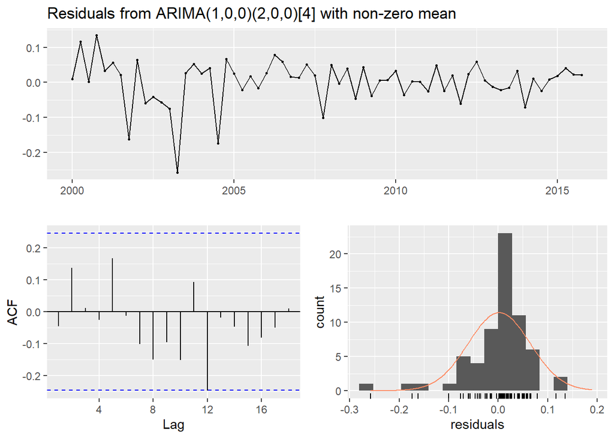

```
##
##  Ljung-Box test
##
## data:  Residuals from ARIMA(1,0,0)(2,0,0)[4] with non-zero mean
## Q* = 5.9242, df = 4, p-value = 0.2049
##
## Model df: 4.   Total lags used: 8
```

```r
checkresiduals(fit0.austourists)
```

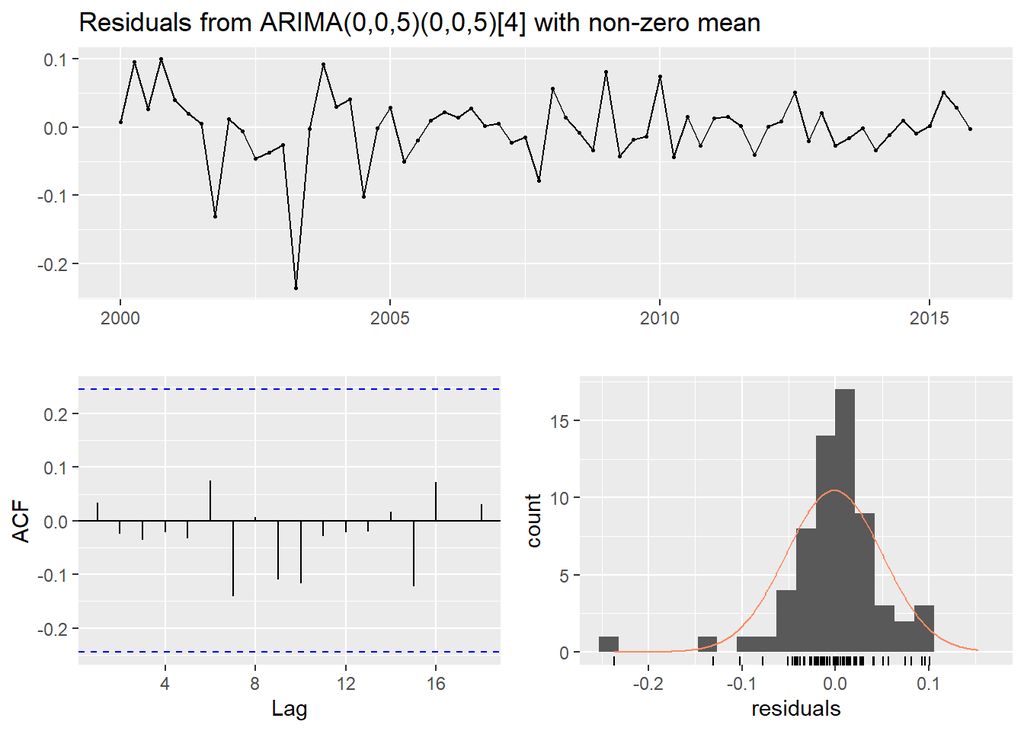

```
##
##  Ljung-Box test
##
## data:  Residuals from ARIMA(0,0,5)(0,0,5)[4] with non-zero mean
## Q* = 4.3688, df = 3, p-value = 0.2243
##
## Model df: 11.   Total lags used: 14
```

```r
checkresiduals(fit4.austourists)
```

*f. Write the model in terms of the backshift operator, then without using the backshift operator.*

# 11. Consider usmelec, the total net generation of electricity (in billion kilowatt hours) by the U.S. electric industry (monthly for the period January 1973 – June 2013). In general there are two peaks per year: in mid-summer and mid-winter.

*a. Examine the 12-month moving average of this series to see what kind of trend is involved.*

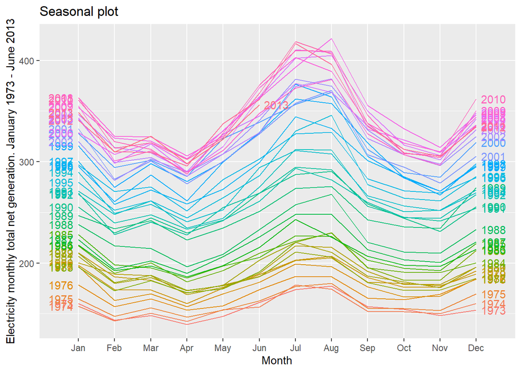

```r
?usmelec

ggseasonplot(usmelec, year.labels=TRUE, year.labels.left=TRUE) +
  ylab("Electricity monthly total net generation. January 1973 - June 2013") +
  ggtitle("Seasonal plot")
```

```r
ma(usmelec, order=12)
```

```
##           Jan      Feb      Mar      Apr      May      Jun      Jul
## 1973       NA       NA       NA       NA       NA       NA 155.2270
## 1974 155.7817 155.8345 155.5156 155.2485 155.2457 155.5931 156.1544
## 1975 158.0824 158.2750 158.6411 158.8897 159.1378 159.6621 160.6457
## 1976 164.9953 165.6763 166.3639 167.1396 168.1868 169.4712 170.8284
## 1977 174.9250 175.8500 176.7244 177.3034 177.3317 177.2686 177.3473
## 1978 180.1669 180.7533 181.5700 182.3480 183.1134 183.8016 184.6097
## 1979 187.9230 187.8403 187.5743 187.5373 187.7590 187.6860 187.1515
## 1980 187.8660 188.9103 189.7958 190.1929 190.1850 190.5133 191.0692
## 1981 192.1681 192.1101 191.7085 191.6315 191.6239 191.4988 191.6202
## 1982 190.1365 189.5308 189.0757 188.4689 188.0281 187.4839 186.4551
## 1983 185.1898 186.6016 188.2367 189.2745 190.0886 191.6373 193.6644
## 1984 201.4065 201.4240 201.3795 201.6961 202.3393 202.1355 202.0897
## 1985 203.4207 203.5137 203.6826 204.1474 204.3932 205.2809 205.6505
## 1986 206.4933 207.1211 207.2590 207.5572 207.8476 207.7769 207.7593
```

[output cut: 69 more lines]

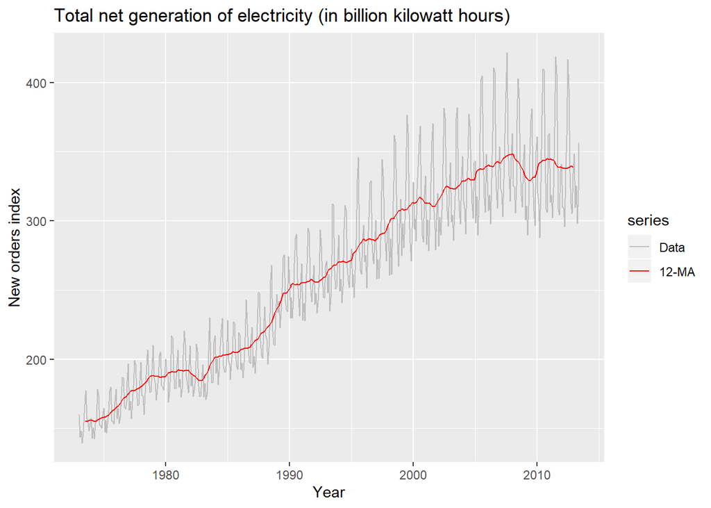

```r
autoplot(usmelec, series="Data") +
  autolayer(ma(usmelec, 12), series="12-MA") +
  xlab("Year") + ylab("New orders index") +
  ggtitle("Total net generation of electricity (in billion kilowatt hours)") +
  scale_colour_manual(values=c("Data"="grey","12-MA"="red"),
                      breaks=c("Data","12-MA"))
```

There is definite upward trend, and I suspect seasonality as well when looking at the raw data over time, as confirmed by the ggseasonplot. Seasonality is also warping to have a sharper climb in the summer months, likely due to increased need for A/C in hotter summers. Because there is trend, the data will need transforming in order to achieve a stationary series. I’ll first try taking the log, BC transformation, and then first-order differencing:

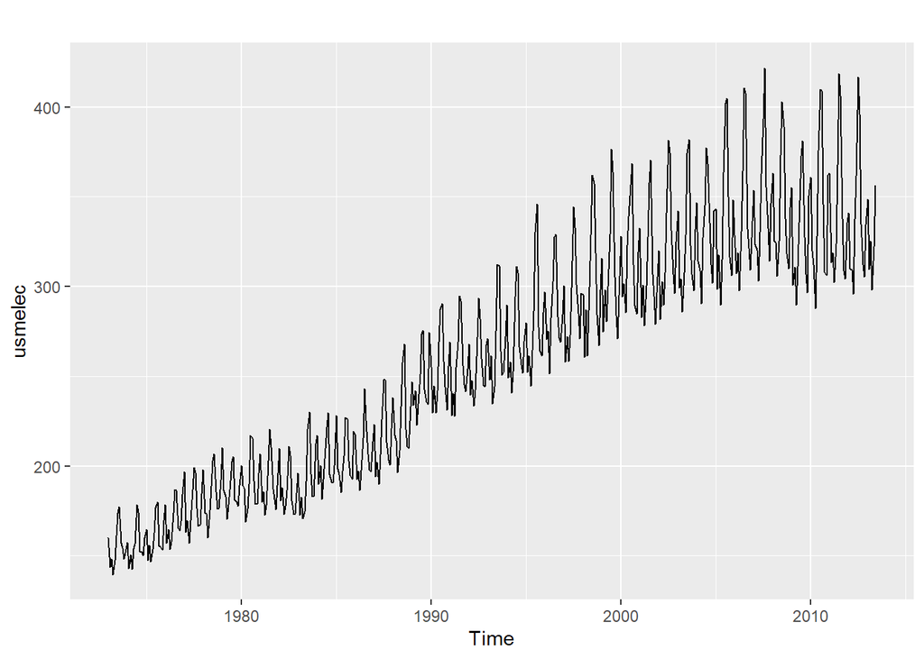

```r
autoplot(usmelec)
```

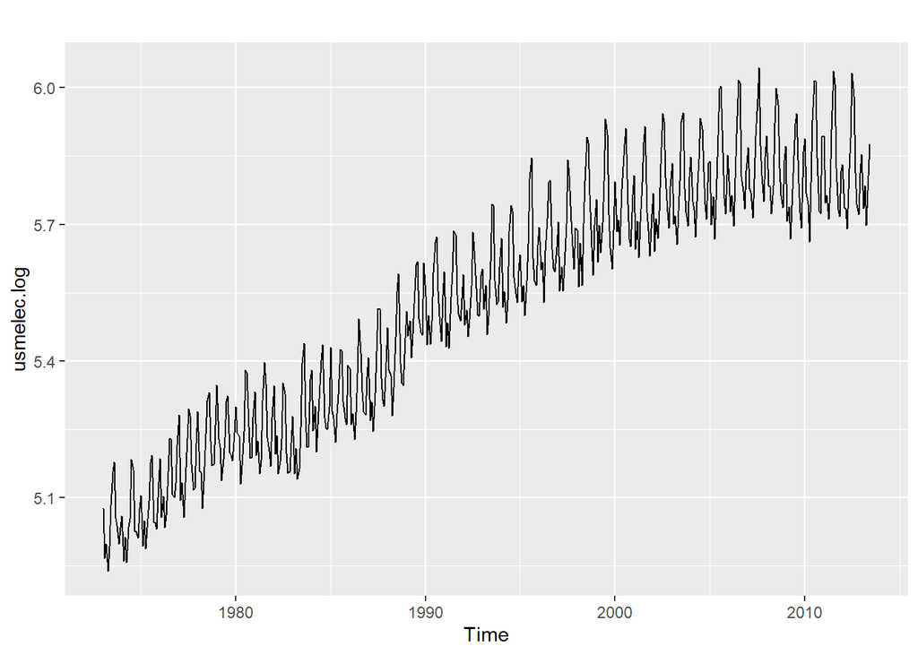

```r
usmelec.log<- log(usmelec)
autoplot(usmelec.log)
```

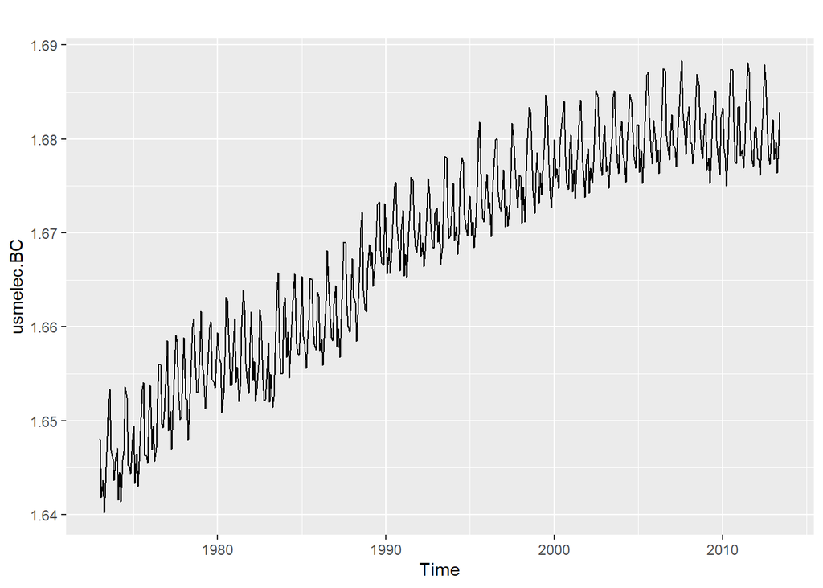

```r
usmelec.BC <- BoxCox(usmelec, lambda="auto")
autoplot(usmelec.BC)
```

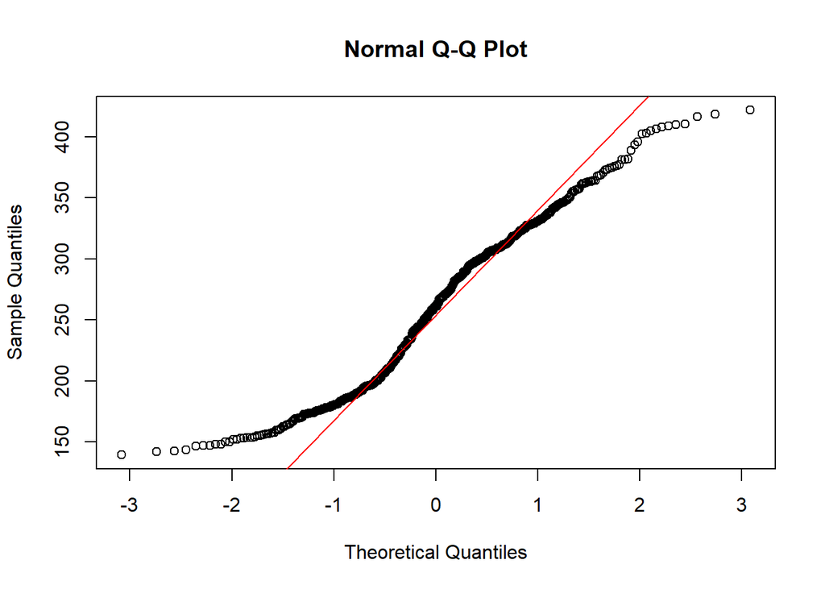

```r
qqnorm(usmelec)
qqline(usmelec, col = 2)
```

```r
skewness(usmelec)
```

```
## [1] 0.1449385
```

```r
kurtosis(usmelec)
```

```
## [1] 1.997959
```

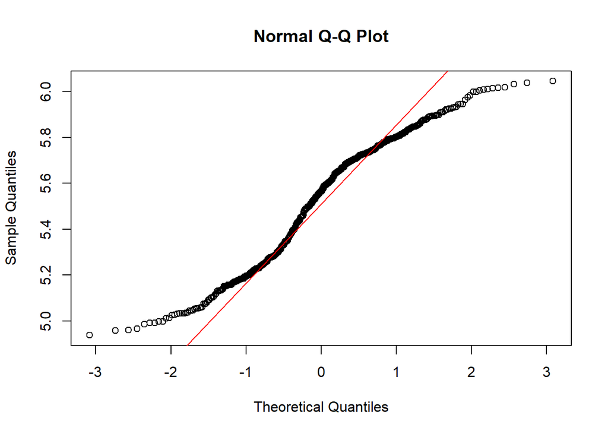

```r
qqnorm(usmelec.log)
qqline(usmelec.log, col = 2)
```

```r
skewness(usmelec.log)
```

```
## [1] -0.2213351
```

```r
kurtosis(usmelec.log)
```

```
## [1] 1.912704
```

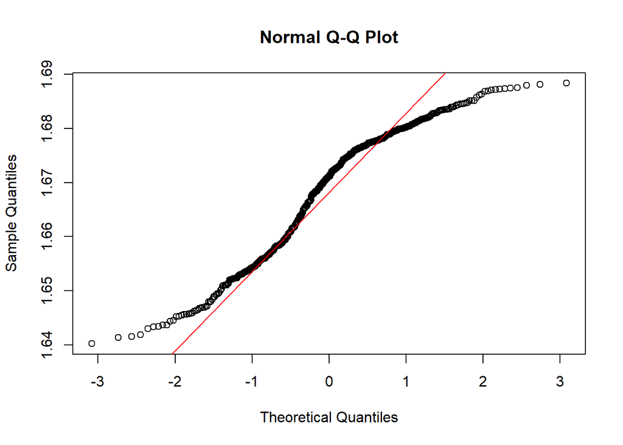

```r
qqnorm(usmelec.BC)
qqline(usmelec.BC, col = 2)
```

```r
skewness(usmelec.BC)
```

```
## [1] -0.4236808
```

```r
kurtosis(usmelec.BC)
```

```
## [1] 2.041295
```

The QQ plots show me that doing the log or BC transformation will only give me negative skewness values, which means that the distribution is not any more even. I will just try to seasonally difference the data from the original ts:

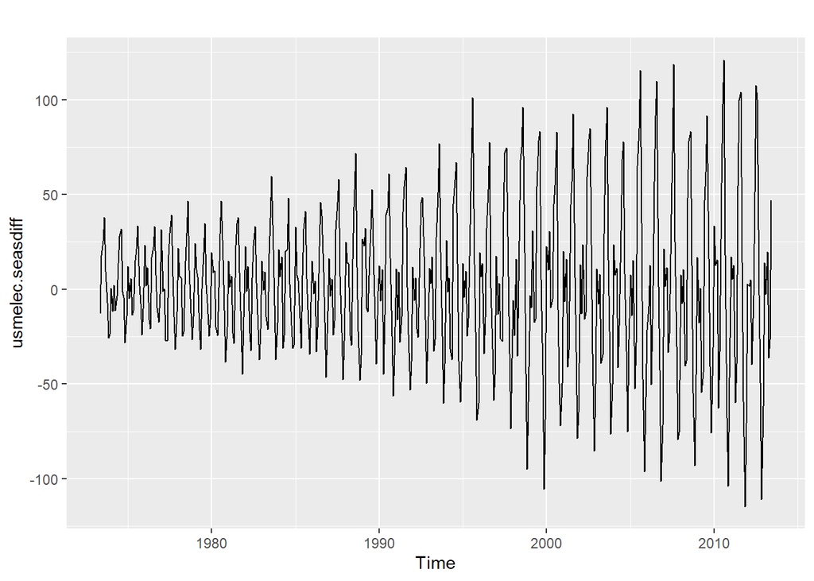

```r
usmelec.seasdiff <- diff(usmelec, 4)
autoplot(usmelec.seasdiff)
```

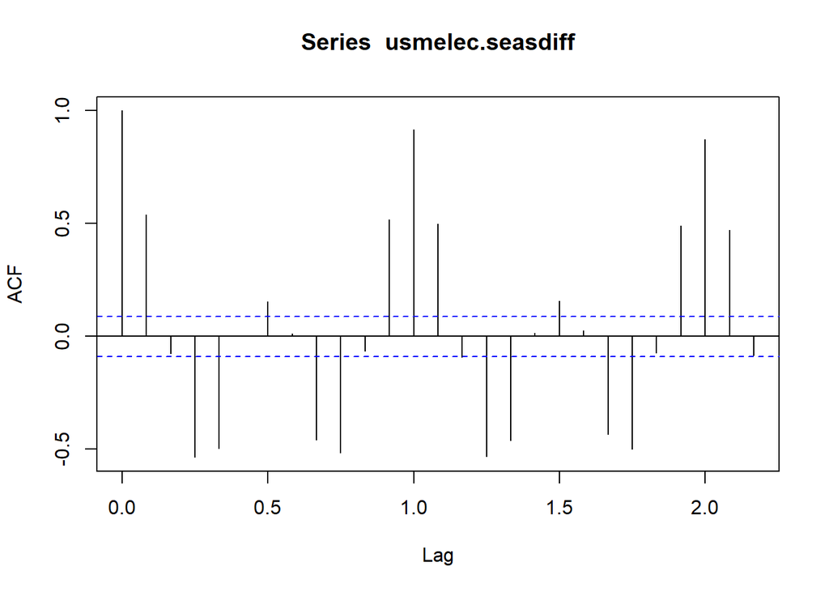

```r
acf(usmelec.seasdiff)
```

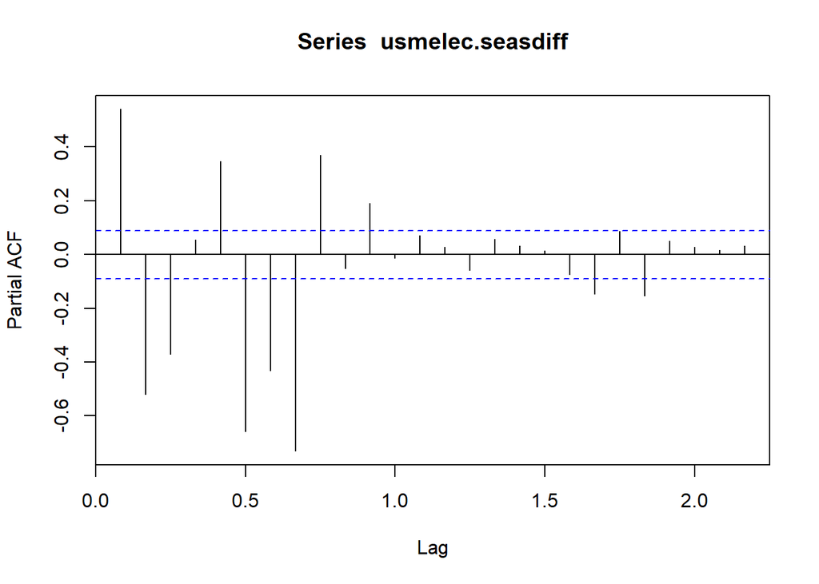

```r
pacf(usmelec.seasdiff)
```

```r
Box.test(usmelec.seasdiff)
```

```
##
##  Box-Pierce test
##
## data:  usmelec.seasdiff
## X-squared = 140.58, df = 1, p-value < 2.2e-16
```

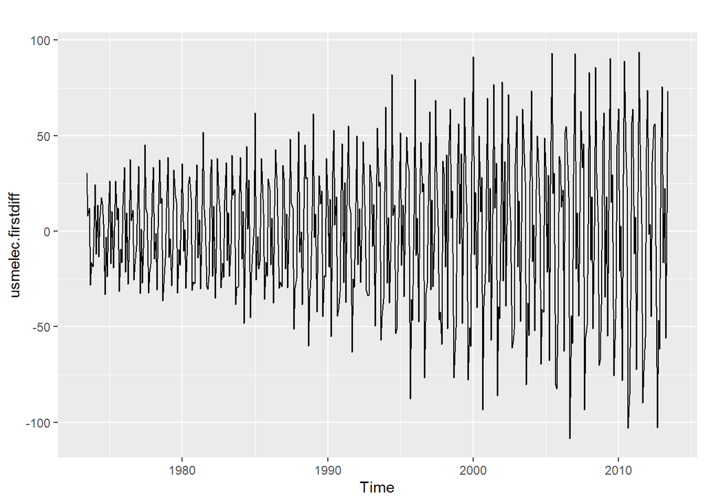

```r
usmelec.firstdiff <- diff(usmelec.seasdiff)
autoplot(usmelec.firstdiff)
```

```r
ndiffs(usmelec, alpha = 0.05) #advises to keep d constant at first order
```

```
## [1] 1
```

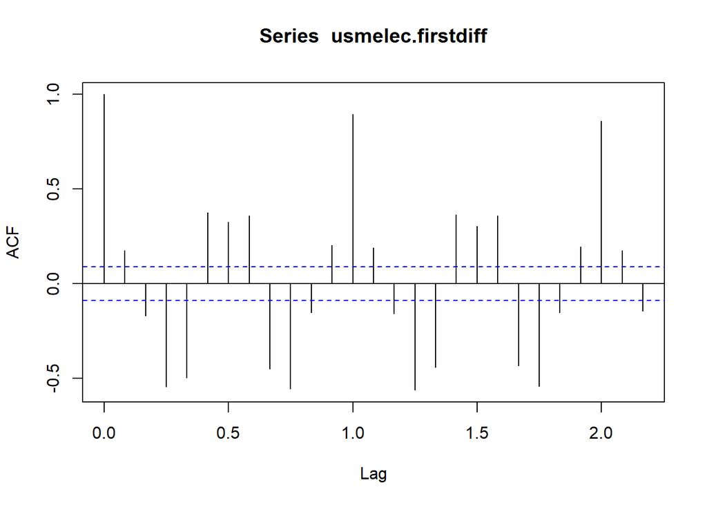

```r
acf(usmelec.firstdiff)
```

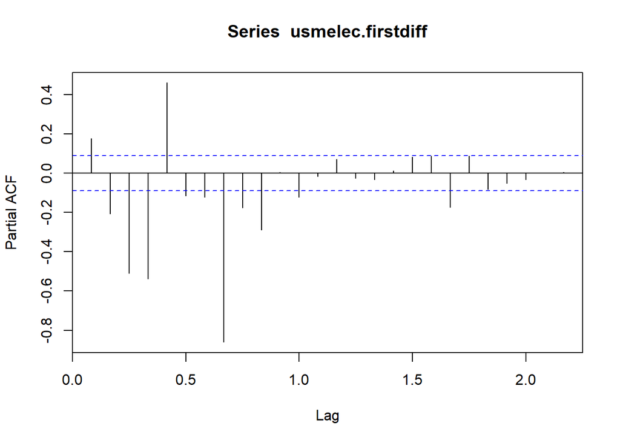

```r
pacf(usmelec.firstdiff)
```

```r
Box.test(usmelec.firstdiff)
```

```
##
##  Box-Pierce test
##
## data:  usmelec.firstdiff
## X-squared = 14.765, df = 1, p-value = 0.0001218
```

```r
summary(ur.kpss(usmelec.firstdiff))
```

```
##
## #######################
## # KPSS Unit Root Test #
## #######################
##
## Test is of type: mu with 5 lags.
##
## Value of test-statistic is: 0.0097
##
## Critical value for a significance level of:
##                 10pct  5pct 2.5pct  1pct
## critical values 0.347 0.463  0.574 0.739
```

*c. Are the data stationary? If not, find an appropriate differencing which yields stationary data.*

p = 4-12 significant lags on PACF d = 1 q = 10-28 significant lags on ACF

*d. Identify a couple of ARIMA models that might be useful in describing the time series. Which of your models is the best according to their AIC values?*

```r
fit1.usmelec <- Arima(usmelec.firstdiff, order=c(4,1,0), seasonal=c(4,1,0))
fit2.usmelec <- Arima(usmelec.firstdiff, order=c(0,1,10), seasonal=c(0,1,10))

fit1.usmelec
```

```
## Series: usmelec.firstdiff
## ARIMA(4,1,0)(4,1,0)[12]
##
## Coefficients:
##           ar1      ar2      ar3      ar4     sar1     sar2     sar3
##       -0.7920  -0.6263  -0.1984  -0.3632  -0.6793  -0.5318  -0.3990
## s.e.   0.0439   0.0574   0.0561   0.0432   0.0485   0.0573   0.0561
##          sar4
##       -0.0872
## s.e.   0.0488
##
## sigma^2 estimated as 165.1:  log likelihood=-1860.9
## AIC=3739.79   AICc=3740.19   BIC=3777.13
```

```r
fit2.usmelec
```

```
## Series: usmelec.firstdiff
## ARIMA(0,1,10)(0,1,10)[12]
##
## Coefficients:
##           ma1     ma2     ma3      ma4     ma5     ma6      ma7     ma8
##       -1.3652  0.1075  0.2577  -0.9945  1.2565  0.0678  -0.3913  0.1288
## s.e.   0.0289  0.0791  0.0815   0.0722  0.0798  0.0821   0.0775  0.0787
##           ma9     ma10     sma1     sma2    sma3    sma4     sma5    sma6
##       -0.0287  -0.0386  -0.8190  -0.0615  0.0420  0.1198  -0.0150  0.1667
## s.e.   0.0810   0.0331   0.0524   0.0618  0.0609  0.0639   0.0661  0.0623
##          sma7    sma8     sma9   sma10
##       -0.0750  0.0190  -0.1412  0.1556
## s.e.   0.0672  0.0735   0.0703  0.0564
##
## sigma^2 estimated as 56.44:  log likelihood=-1624.96
## AIC=3291.92   AICc=3293.99   BIC=3379.04
```

The AICC for both is extremely high, so I’m going to disregard my ACF and PACF lags and try some simpler values before I do auto.arima():

```r
fit3.usmelec <- Arima(usmelec.firstdiff, order=c(1,1,0), seasonal=c(1,1,0))
fit4.usmelec <- Arima(usmelec.firstdiff, order=c(0,1,1), seasonal=c(0,1,1))

fit3.usmelec
```

```
## Series: usmelec.firstdiff
## ARIMA(1,1,0)(1,1,0)[12]
##
## Coefficients:
##           ar1     sar1
##       -0.5553  -0.4279
## s.e.   0.0384   0.0417
##
## sigma^2 estimated as 357.1:  log likelihood=-2039.93
## AIC=4085.86   AICc=4085.92   BIC=4098.31
```

```r
fit4.usmelec
```

```
## Series: usmelec.firstdiff
## ARIMA(0,1,1)(0,1,1)[12]
##
## Coefficients:
##          ma1     sma1
##       -1.000  -0.7297
## s.e.   0.006   0.0270
##
## sigma^2 estimated as 159.3:  log likelihood=-1858.47
## AIC=3722.95   AICc=3723   BIC=3735.39
```

This isn’t stationary enough to build a fit from, so I’m going to attempt rebuilding from an alternate class example:

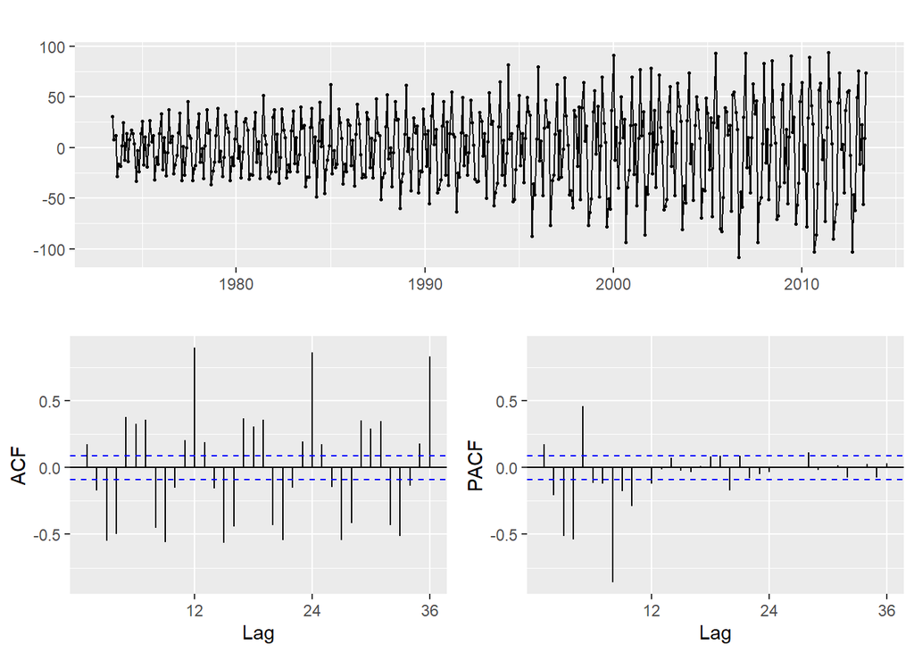

```r
usmelec %>% diff(lag=4) %>% diff() %>% ggtsdisplay()
```

```r
usmelec.sd.fd <- euretail %>% diff(lag=4) %>% diff()

ndiffs(usmelec.sd.fd)
```

```
## [1] 0
```

Let’s try one more manual arima:

```r
fit5.usmelec <- Arima(usmelec.sd.fd, order=c(6,0,3), seasonal=c(6,0,3))
fit5.usmelec
```

```
## Series: usmelec.sd.fd
## ARIMA(6,0,3)(6,0,3)[4] with non-zero mean
##
## Coefficients:
##           ar1     ar2     ar3      ar4      ar5      ar6     ma1     ma2
##       -0.1273  0.1302  0.8480  -0.0929  -0.1556  -0.3500  0.4824  0.2653
## s.e.   0.3292  0.2593  0.1637   0.2217   0.1778   0.1363  0.3466  0.3896
##           ma3     sar1     sar2    sar3     sar4     sar5    sar6    sma1
##       -0.6491  -1.5306  -0.6428  0.2050  -0.0288  -0.1296  0.0686  0.6818
## s.e.   0.3435   0.3718   0.4741  0.3922   0.4269   0.3743  0.2524  0.3487
##          sma2     sma3     mean
##       -0.6815  -0.9999  -0.0486
## s.e.   0.3465   0.3230   0.0159
##
## sigma^2 estimated as 0.1217:  log likelihood=-22.05
## AIC=84.09   AICc=106.2   BIC=125.64
```

```r
fit0.usmelec <- auto.arima(usmelec.sd.fd, seasonal=TRUE)

fit0.usmelec
```

```
## Series: usmelec.sd.fd
## ARIMA(2,0,0)(0,0,1)[4] with zero mean
##
## Coefficients:
##          ar1     ar2     sma1
##       0.3305  0.2895  -0.8337
## s.e.  0.1307  0.1308   0.1492
##
## sigma^2 estimated as 0.1595:  log likelihood=-30.32
## AIC=68.64   AICc=69.38   BIC=76.95
```

*e. Estimate the parameters of your best model and do diagnostic testing on the residuals. Do the residuals resemble white noise? If not, try to find another ARIMA model which fits better.*

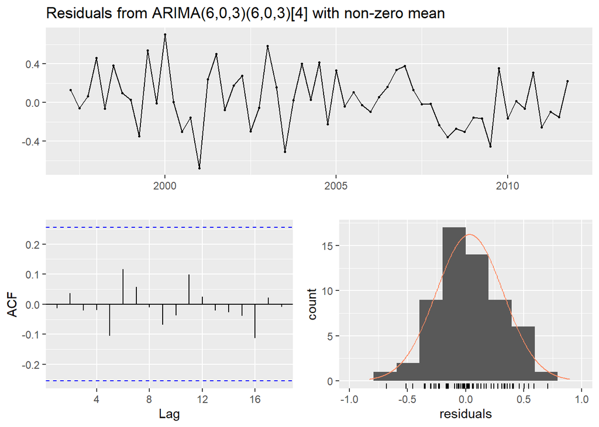

```
##
##  Ljung-Box test
##
## data:  Residuals from ARIMA(6,0,3)(6,0,3)[4] with non-zero mean
## Q* = 5.1641, df = 3, p-value = 0.1602
##
## Model df: 19.   Total lags used: 22
```

```r
checkresiduals(fit5.usmelec)
```

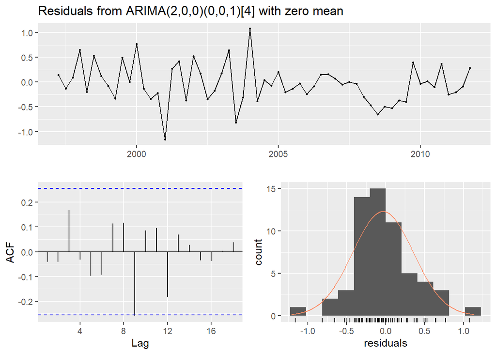

```
##
##  Ljung-Box test
##
## data:  Residuals from ARIMA(2,0,0)(0,0,1)[4] with zero mean
## Q* = 5.2026, df = 5, p-value = 0.3917
##
## Model df: 3.   Total lags used: 8
```

```r
checkresiduals(fit0.usmelec)
```

*f. Forecast the next 15 years of electricity generation by the U.S. electric industry. Get the latest figures from the EIA to check the accuracy of your forecasts.*

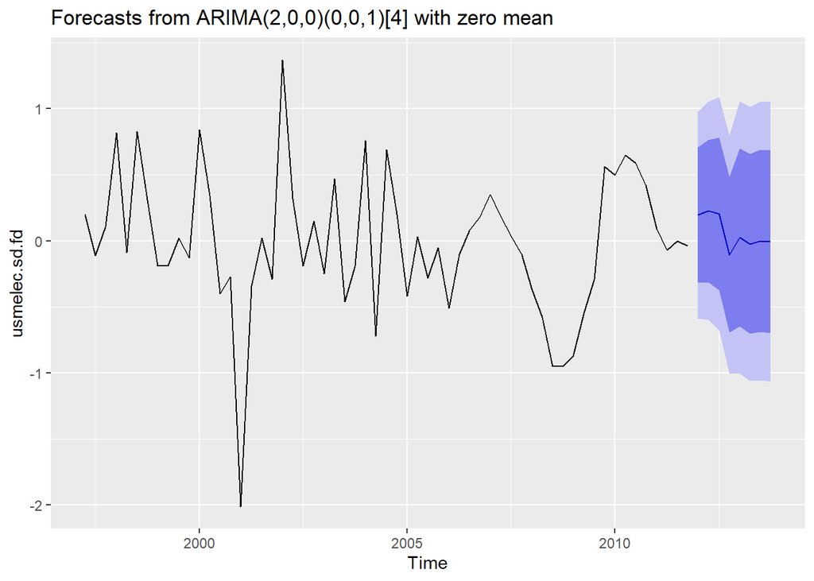

```r
autoplot(forecast(fit0.usmelec), start=1988, h=180)
```

*g. Eventually, the prediction intervals are so wide that the forecasts are not particularly useful. How many years of forecasts do you think are sufficiently accurate to be usable?*

For this example specifically, I personally would not go further than a decade in the future, and would even feel more comfortable within the five year range. Because this is monthly data, and seasonality is also increasing along with trend, I would be hesitant to build a long forecast.